# Project

Anna Ma

2/18/2022

```r
library(flexsurv)
library(coxed)
library(survival)
library(simsurv)
library(MASS)
library(tidyverse)
library(nph)
```

## Proportional hazard model

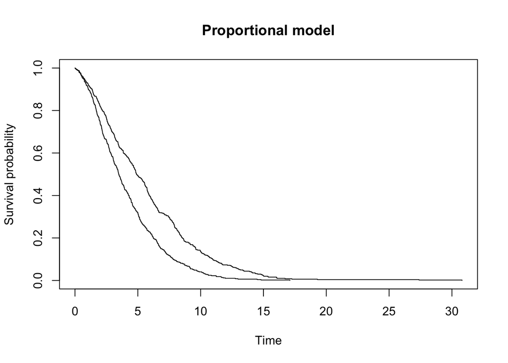

```r
set.seed(123456)
N = 1000 ## number of patients/observations
covs = data.frame(id = 1:N,
                  trt = rbinom(N, 1, 0.5)) ## Covariates of each observation

s1 = simsurv(lambdas = 0.1, gammas = 1.5, x = covs, betas = c(trt = -0.5), maxt = 100) ## Simulate survival data

dat = merge(covs, s1)
mod <- flexsurvspline(Surv(eventtime, status) ~ trt, data = dat) ## Create survival object

plot(survfit(Surv(eventtime, status) ~ trt, data = dat), main = "Proportional model", ylab = "Survival probability",
     xlab = "Time")
```

```r
logrank.test(dat$eventtime, dat$status, dat$trt, rho = 0, gamma = 0 )
```

```
## Call:
## logrank.test(time = dat$eventtime, event = dat$status, group = dat$trt,
##     rho = 0, gamma = 0)
##
##     N Observed Expected (O-E)^2/E (O-E)^2/V
## 1 495      495      382      33.4      56.6
## 2 505      501      614      20.8      56.6
##
##  Chisq= 56.6  on 1 degrees of freedom, p= 5e-14
##  rho   =  0 gamma =  0
```

```r
logrank.test(dat$eventtime, dat$status, dat$trt, rho = 0, gamma = 1 )
```

```
## Call:
## logrank.test(time = dat$eventtime, event = dat$status, group = dat$trt,
##     rho = 0, gamma = 1)
##
##     N Observed Expected (O-E)^2/E (O-E)^2/V
## 1 495      495      382      33.4       195
## 2 505      501      614      20.8       195
##
##  Chisq= 47.4  on 1 degrees of freedom, p= 6e-12
##  rho   =  0 gamma =  1
```

```r
logrank.test(dat$eventtime, dat$status, dat$trt, rho = 1, gamma = 0 )
```

```
## Call:
## logrank.test(time = dat$eventtime, event = dat$status, group = dat$trt,
##     rho = 1, gamma = 0)
##
##     N Observed Expected (O-E)^2/E (O-E)^2/V
## 1 495      495      382      33.4       155
## 2 505      501      614      20.8       155
##
##  Chisq= 40  on 1 degrees of freedom, p= 3e-10
##  rho   =  1 gamma =  0
```

```r
logrank.maxtest(dat$eventtime, dat$status, dat$trt)
```

```
## Call:
## logrank.maxtest(time = dat$eventtime, event = dat$status, group = dat$trt)
##
##  Two sided p-value = 9.08e-14 (Bonferroni corrected: 1.63e-13)
##
##  Individual weighted log-rank tests:
##   Test    z        p
## 1    1 7.52 5.42e-14
## 2    2 6.88 5.94e-12
## 3    3 6.33 2.52e-10
```

Log-rank test: the Chi-Squared test statistic is 56.6 with 1 degree of freedom and the corresponding p-value is 5.4e-14, we reject the null hypothesis.

Log-rank test for a late effect: the Chi-Squared test statistic is 47.4 with 1 degree of freedom and the corresponding p-value is 6.0e-12, we reject the null hypothesis.

Log-rank test for an early effect: the Chi-Squared test statistic is 40 with 1 degree of freedom and the corresponding p-value is 2.5e-10, we reject the null hypothesis.

All three log-rank tests successfully reject the null hypothesis.

## Non-proportional hazard model

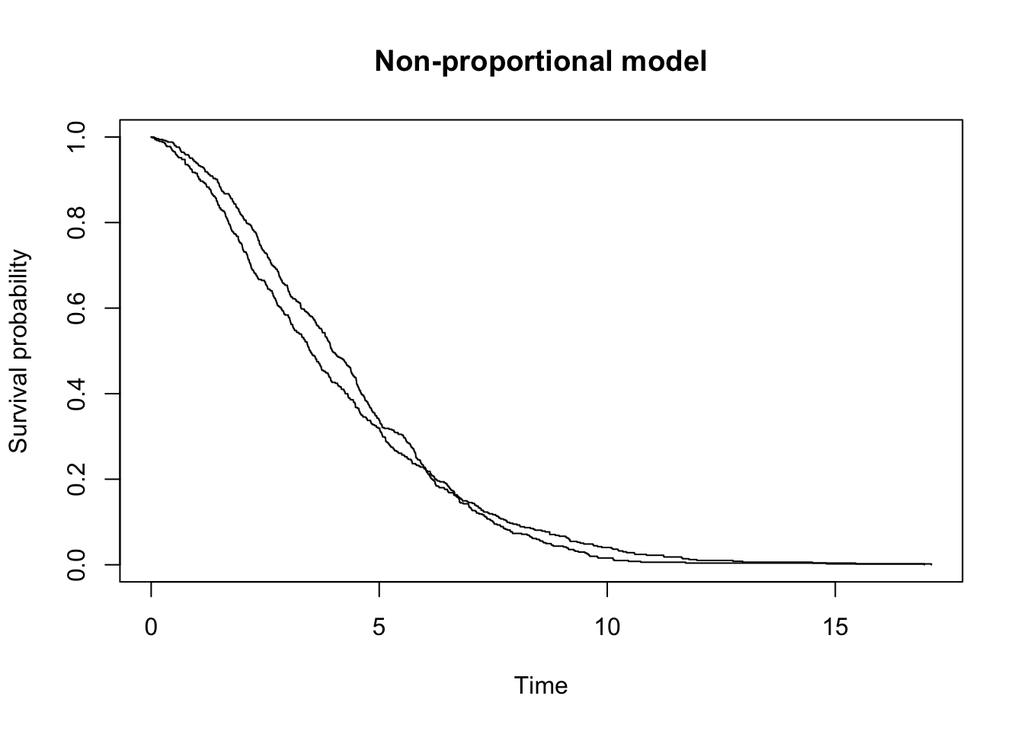

```r
set.seed(123456)
N = 1000 ## number of patients/observations
covs2 = data.frame(id = 1:N,
                  trt = rbinom(N, 1, 0.5)) ## Covariates of each observation

pars_tde = c(trt = 0.4)

s2 <- simsurv(lambdas = 0.1, gammas = 1.5, x = covs, betas = c(trt = -0.5), tde = pars_tde, tdefunction = 'log')

dat2 =  merge(s2, covs2)
mod2 <- flexsurvspline(Surv(eventtime, status) ~ trt, data = dat2)

plot(survfit(Surv(eventtime, status) ~ trt, data = dat2), main = "Non-proportional model", ylab = "Survival probability",
     xlab = "Time")
```

```r
logrank.test(dat2$eventtime, dat2$status, dat2$trt, rho = 0, gamma = 0 )
```

```
## Call:
## logrank.test(time = dat2$eventtime, event = dat2$status, group = dat2$trt,
##     rho = 0, gamma = 0)
##
##     N Observed Expected (O-E)^2/E (O-E)^2/V
## 1 495      494      490    0.0363    0.0721
## 2 505      505      509    0.0349    0.0721
##
##  Chisq= 0.1  on 1 degrees of freedom, p= 0.8
##  rho   =  0 gamma =  0
```

```r
logrank.test(dat2$eventtime, dat2$status, dat2$trt, rho = 0, gamma = 1 )
```

```
## Call:
## logrank.test(time = dat2$eventtime, event = dat2$status, group = dat2$trt,
##     rho = 0, gamma = 1)
##
##     N Observed Expected (O-E)^2/E (O-E)^2/V
## 1 495      494      490    0.0363      0.22
## 2 505      505      509    0.0349      0.22
##
##  Chisq= 3.1  on 1 degrees of freedom, p= 0.08
##  rho   =  0 gamma =  1
```

```r
logrank.test(dat2$eventtime, dat2$status, dat2$trt, rho = 1, gamma = 0 )
```

```
## Call:
## logrank.test(time = dat2$eventtime, event = dat2$status, group = dat2$trt,
##     rho = 1, gamma = 0)
##
##     N Observed Expected (O-E)^2/E (O-E)^2/V
## 1 495      494      490    0.0363     0.214
## 2 505      505      509    0.0349     0.214
##
##  Chisq= 4.9  on 1 degrees of freedom, p= 0.03
##  rho   =  1 gamma =  0
```

```r
logrank.maxtest(dat2$eventtime, dat2$status, dat2$trt)
```

```
## Call:
## logrank.maxtest(time = dat2$eventtime, event = dat2$status, group = dat2$trt)
##
##  Two sided p-value = 0.0555 (Bonferroni corrected: 0.0829)
##
##  Individual weighted log-rank tests:
##   Test      z      p
## 1    1  0.269 0.7883
## 2    2 -1.762 0.0781
## 3    3  2.203 0.0276
```

Log-rank test: the Chi-Squared test statistic is 0.0721 with 1 degree of freedom and the corresponding p-value is 0.7883, so we fail to reject the null hypothesis.

Log-rank test for a late effect: the Chi-Squared test statistic is 3.1 with 1 degree of freedom and the corresponding p-value is 0.0781, so we fail to reject the null hypothesis.

Log-rank test for an early effect: the Chi-Squared test statistic is 4.9 with 1 degree of freedom and the corresponding p-value is 0.0276, so we reject the null hypothesis.

Therefore, when the hazard model is time-dependent, only the log-rank test for an early effect successfully rejects the null hypothesis.